# Homework 2: The Big Short

**This homework is due Friday February 26, 2016 at 5:00 PM. When complete, submit your code in the R Markdown file and the knitted HTML via GitHub.**

# Background

This homework is motivated by circumstances surrounding the [financial crisis of 2007-2008](https://en.wikipedia.org/wiki/Financial_crisis_of_2007%E2%80%9308). We titled the homework *The Big Short*, after the book on the same topic that was also recently made into a movie.

Part of what caused the financial crisis was that the risk of certain securities sold by financial institutions were underestimated. Specifically, the risk of mortgage-backed securities (MBS) and collateralized debt obligations (CDO), the price of which depends on homeowners making their monthly payments, was grossly underestimated. A combination of factors resulted in many more defaults than were expected. This resulted in a crash of the prices of these securities. As a consequence, banks lost so much money that they needed bailouts to avoid default.

Here we present a **very** simplified version of what happened with some of these securities. Hopefully it will help you understand how a wrong assumption about the statistical behavior of events can lead to substantial differences between what the model predicts and what actually happens. Specifically, we will see how using an independence assumption can result in misleading conclusions. Before we start with the specific application we ask you about a simple casino game.

# Problem 1

In the game of [roullete](https://en.wikipedia.org/wiki/Roulette) you can bet on several things including black or red. On this bet, if you win, you double your earnings. How does the casino make money on this then? If you look at the [possibilities](http://www.math.uah.edu/stat/games/Roulette.png) you realize that the chance of red or black are both slightly less than 1/2. There are two green spots, so the of landing on black (or red) is actually 18/38, or 9/19.

## Problem 1A

Let’s make a quick sampling model for this simple version of roulette. You are going to bet a dollar each time you play and always bet on black. Make a box model for this process using the `sample` function. Write a function `get_outcome` that takes as an argument the number of times you play $N$ and returns your earnings $S_N$.

```r
get_outcome <- function(n){
  box <- rep( c("black", "red", "green"), times = c(18,18,2))
  playgame <- replicate(n, sample(box, 1))
  return( sum(playgame=="black")-sum(playgame=="red")-sum(playgame=="green"))
}
get_outcome(10)
```

```
## [1] -4
```

## Problem 1B

Use Monte Carlo simulation to study the distribution of total earnings $S_N$ for $N=10,25,100,1000$. That is, study the distribution of earnings for different number of plays. What are the distributions of these two random variables? How do the expected values and standard errors change with $N$? Then do the same thing for the average winnings $S_N/N$. What result that you learned in class predicts this?

## The distribution of total earnings

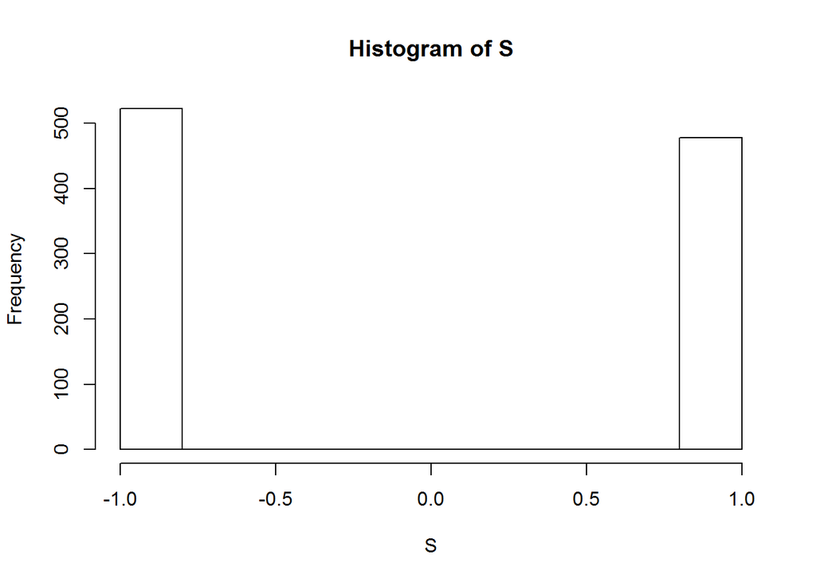

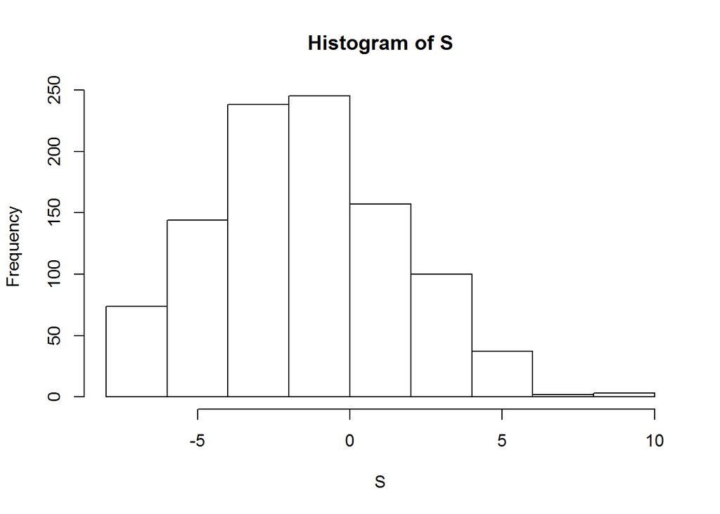

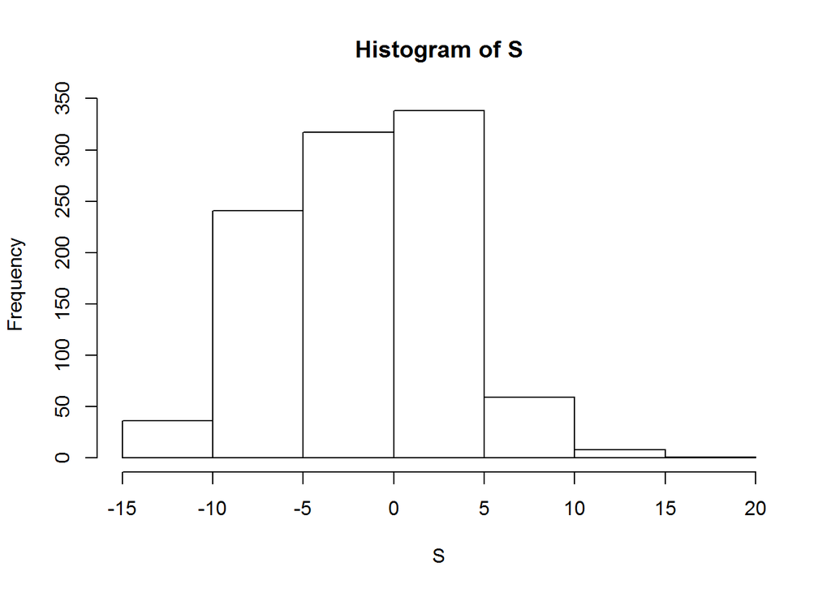

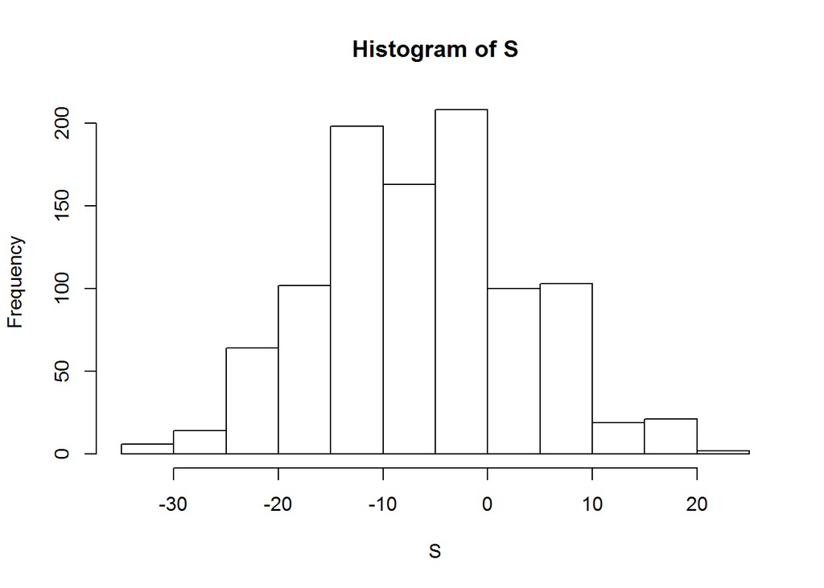

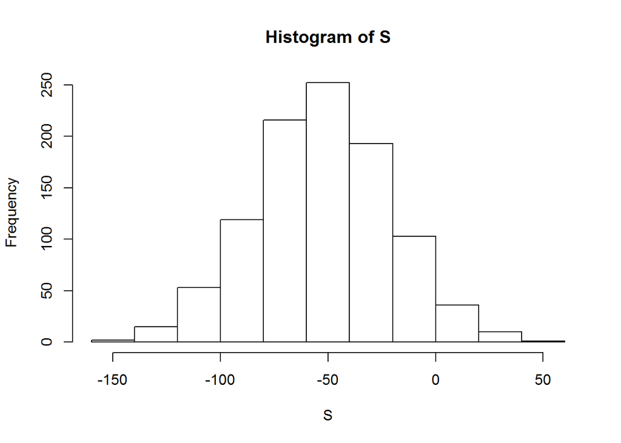

[output not shown]

```r
# What does "these two random variables" mean??
# Is the right equation for standard error?
Sdist <- function(n){
  S <- replicate(1000, get_outcome(n))
  mean <- paste("Expected value of total earnings is", mean(S))
  se <- paste("Standard error of total earnings is", sd(S)/sqrt(length(S)))
  return(c(mean,se,sd(S),hist(S)))
}

k <- c(1,10,25,100,1000)
sapply(k,Sdist)
```

## The distribution of average earnings

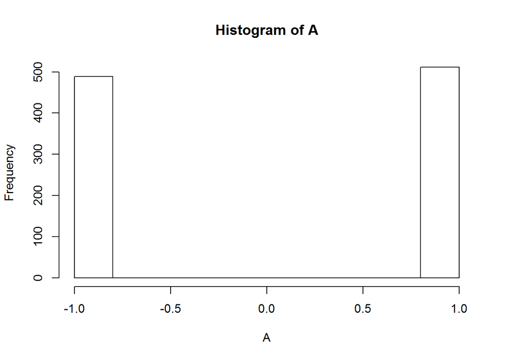

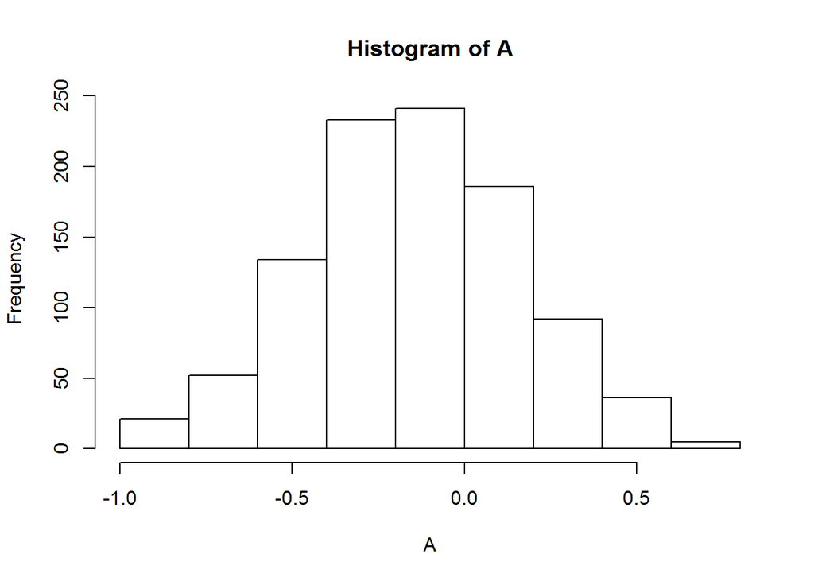

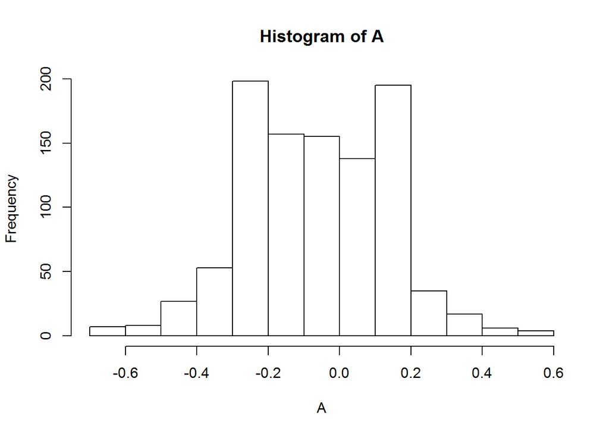

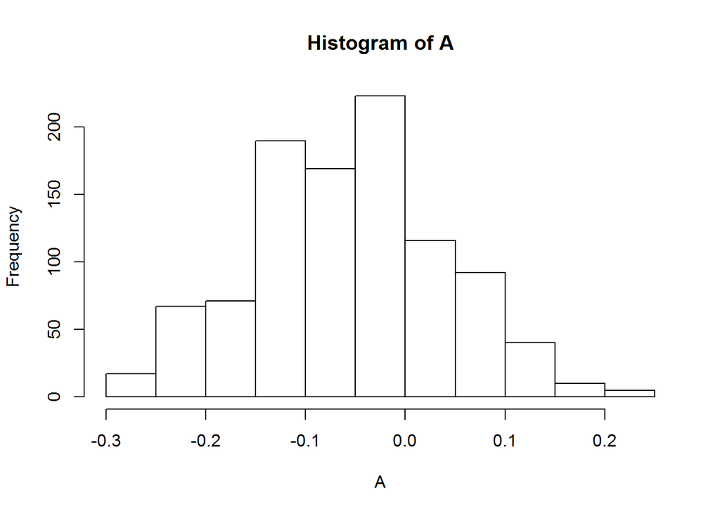

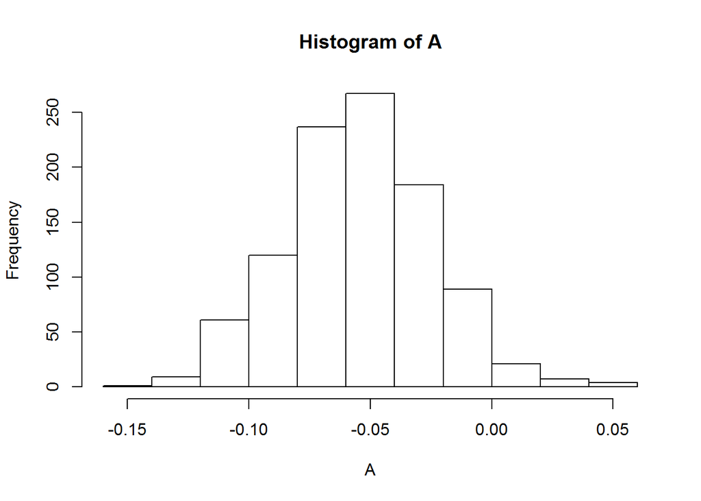

[output not shown]

```r
Sdist2 <- function(n){
  A <- replicate(1000, get_outcome(n)/n)
  mean <- paste("Expected value of average earnings is", mean(A))
  se <- paste("Standard error of average earnings is", sd(A)/sqrt(length(A)))
  return(c(mean,se,sd(A),hist(A)))
}

sapply(k,Sdist2)
```

Your answer here. ### [Answer] For total earning, expected values and standard errors get bigger as N gets bigger since total earning is a summed value. On the other hand, for average earning, the sample averages get closer to the average of expected earning which we want to estimate and standard errors get smaller as N gets bigger, and this is consistent with the Law of Large Numbers.

## Problem 1C

What is the expected value of our sampling model? What is the standard deviation of our sampling model? (For question 1c and other questions, the sampling model relates to urn/box/jar from which you take draws. For example, we used the jar full of blue and read bead as a sampling model for polls. Once you have a sampling model, you can simulate however many draws as you want.)

Your answer here.

### [Answer]

The expected earning per game (average): P(black) x (Value of X for black) + P(Not black) x (Value of X for Not black) = 9/19 x 1 + 10/19 x (-1) = -0.053 The expected earning for 10 games: -0.053*10 = -0.53 dollar The expected earning for 25 games: -0.053*25 = -1.32 dollar The expected earning for 100 games: -0.053*100 = -5.26 dollar The expected earning for 1000 games: -0.053*1000 = -52.63 dollar

The standard deviation for n games: 2*(n*p*q)^0.5 = (n*(9/19)*(10/19))^0.5 The standard deviation for 10 games: 2*(10*(9/19)*(10/19))^0.5 = 3.157894737 The standard deviation for 25 games: 2*(25*(9/19)*(10/19))^0.5 = 4.99306999 The standard deviation for 100 games: 2*(100*(9/19)*(10/19))^0.5 = 9.986139979 The standard deviation for 1000 games: 2*(1000*(9/19)*(10/19))^0.5 = 31.57894737

## Problem 1D

Use CLT to approximate the probability that the casino loses money when you play 25 times. Then use a Monte Carlo simulation to confirm.

```r
# Expected earning for 25 games: -25 + 2*25*(9/19)= -1.32 dollar
pnorm(0, mean=-1.32, sd=4.99306999, lower.tail=FALSE)
```

```
## [1] 0.3957488
```

```r
S <- replicate(1000, get_outcome(25))
prop.table(table(S > 0))
```

```
##
## FALSE  TRUE
## 0.597 0.403
```

```r
A <- replicate(1000, get_outcome(25)/25)
prop.table(table(A > 0))
```

```
##
## FALSE  TRUE
## 0.601 0.399
```

## Problem 1E

In general, what is the probability that the casino loses money as a function of $N$? Make a plot for values ranging from 25 to 1,000. Why does the casino give you free drinks if you keep playing?

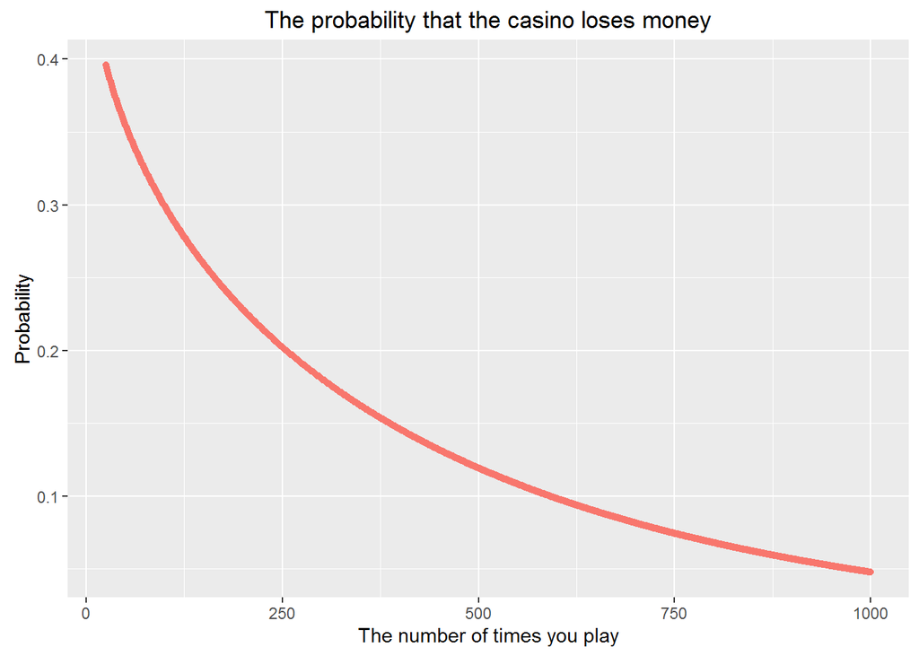

```r
# Expected earning for n games: n*{(1)*(9/19)+(-1)*(10/19)} = -n/19
n <- (25:1000)
casinolose <- function(n){
  return(pnorm(0, mean=(-n/19), sd=2*(n*(9/19)*(10/19))^0.5, lower.tail=F))
}

library(ggplot2)
qplot(n, casinolose(n), color = "cyl", geom = "point") +
  labs(title ="The probability that the casino loses money", x = "The number of times you play", y = "Probability") +
  theme(legend.position="none")
```

Your answer here.

### [Answer] As we can see from the plot, the probability that the casino loses money gets smaller, the more we play the game. When we play the game 25 times, the probability that we would win is only about 0.4 (not even 0.5), and the probability is getting lower and it is close to zero if we play the game more than 1000 times. This is the reason why the casino give us free drinks if we keep playing because we might have been losing money.

# Problem 2

You run a bank that has a history of identifying potential homeowners that can be trusted to make payments. In fact, historically, in a given year, only 2% of your customers default. You want to use stochastic models to get an idea of what interest rates you should charge to guarantee a profit this upcoming year.

## Problem 2A

Your bank gives out 1,000 loans this year. Create a sampling model and use the function `sample` to simulate the number of foreclosure in a year with the information that 2% of customers default. Also suppose your bank loses $120,000 on each foreclosure. Run the simulatqion for one year and report your loss.

```r
# n: the number of loans this year = 1000
bankloss <- function(n){
  foreclosure <- sum(sample(c(1,0), n, replace=T, prob=c(0.02, 0.98)))
  loss <- foreclosure*(-120000)
  return(c(
    paste("The number of foreclosure out of",n,"loans is",foreclosure,"for one year."),
    paste("The yearly loss due to foreclosure is",loss,"for one year.")
    )
)}
bankloss(1000)
```

```
## [1] "The number of foreclosure out of 1000 loans is 17 for one year."
## [2] "The yearly loss due to foreclosure is -2040000 for one year."
```

## Problem 2B

Note that the loss you will incur is a random variable. Use Monte Carlo simulation to estimate the distribution of this random variable. Use summaries and visualization to describe your potential losses to your board of trustees.

```r
# Can I show just summary and plot?
B <- replicate(100, sum(sample(c(1,0), 1000, replace=T, prob=c(0.02, 0.98)))*(-120))
summary(B)
```

```
##    Min. 1st Qu.  Median    Mean 3rd Qu.    Max.
##   -4080   -2760   -2400   -2402   -2040   -1080
```

```r
sd(B)
```

```
## [1] 606.6252
```

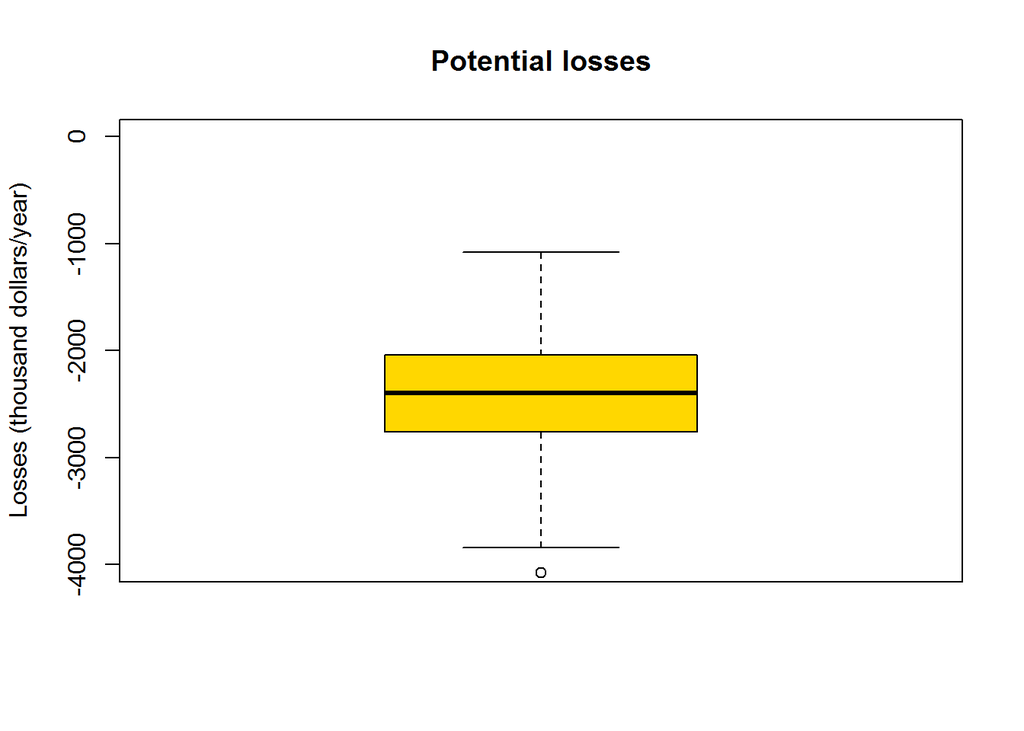

```r
boxplot(B, col="gold", main="Potential losses", ylab="Losses (thousand dollars/year)", ylim = c(-4000, 0))
```

## Problem 2C

The 1,000 loans you gave out were for $180,000. The way your bank can give out loans and not lose money is by charging an interest rate. If you charge an interest rate of, say, 2% you would earn $3,600 for each loan that doesn’t foreclose. At what percentage should you set the interest rate so that your expected profit totals $100,000. Hint: Create a sampling model with expected value 100 so that when multiplied by the 1,000 loans you get an expectation of $100,000. Corroborate your answer with a Monte Carlo simulation.

Your solution here.

```r
# Expected profit per loan = $100 = (1-0.02)*180000*interest_rate - 0.02*120000
# interest_rate = (100+0.02*120000)/((1-0.02)*180000) = 0.01417
# The interest rate should be set at 1.417% to expect profit of $100,000.

# Below Monte Carlo simulation shows that the mean profit per loan is getting closer to $100 as the number of simulation increases.

profit <- function(m){
  I <- mean(replicate(m, (sample(c(1,0), 1000, replace=T, prob=c(0.02, 0.98)))))
  return((1-I)*180000*0.01417 - I*120000)
}
m <- c(10,100,1000,10000)
sapply(m,profit)
```

```
## [1] 197.62848 130.22565  98.36249 104.68610
```

## Problem 2D

In problem 2C, you were able to set a very low interest rate. Your customers will be very happy and you are expected to earn $100,000 in profits. However, that is just an expectation. Our profit is a random variable. If instead of a profit your bank loses money, your bank defaults. Under the conditions of Problem 2C, what is the probability that your profit is less than 0?

```r
# Set the interest rate as 1.417%
# Expected value = (1-p)*180000*0.01417 - p*(120000) should be less than '0'

profit2 <- function(m){
  I <- replicate(m, mean(sample(c(1,0), 1000, replace=T, prob=c(0.02, 0.98))))
  return((1-I)*180000*0.01417 - I*120000)
}
P <- replicate(100, profit2(1000))
prop.table(table(P < 0))
```

```
##
##   FALSE    TRUE
## 0.55959 0.44041
```